# 気象庁 過去データ処理

Y.Hatanaka

2018/11/4

## データ読み込む

試しに，気象庁のサイトの過去データダウンロードから，月ごとのデータをダウンロード。

エディタで見ると（Shift-JIS 注意）…

```
ダウンロードした時刻：2018/11/04 12:47:36

,酒田,酒田,酒田,酒田,酒田,酒田,酒田,酒田,酒田,酒田,酒田,酒田,酒田
年月,平均気温(℃),平均気温(℃),平均気温(℃),日最高気温の平均(℃),日最高気温の平均(℃),日最高気温の平均(℃),日最低気温の平均(℃),日最低気温の平均(℃),日最低気温の平均(℃),降水量の合計(mm),降水量の合計(mm),降水量の合計(mm),降水量の合計(mm)
,,品質情報,均質番号,,品質情報,均質番号,,品質情報,均質番号,,現象なし情報,品質情報,均質番号
1987/1,1.1,8,1,4.0,8,1,-1.8,8,1,140.5,0,8,1
1987/2,1.9,8,1,4.9,8,1,-0.9,8,1,115.0,0,8,1
```

1行目「ダウンロードした…」と2行目（空行），表形式にならないし不要。

3行目以降は

|  | 酒田 | 酒田 | 酒田 | 酒田 | 酒田 | 酒田 | 酒田 | 酒田 | 酒田 | 酒田 | 酒田 | 酒田 | 酒田 |
| --- | --- | --- | --- | --- | --- | --- | --- | --- | --- | --- | --- | --- | --- |
| 年月 | 平均気温(℃) | 平均気温(℃) | 平均気温(℃) | 日最高気温の平均(℃) | 日最高気温の平均(℃) | 日最高気温の平均(℃) | 日最低気温の平均(℃) | 日最低気温の平均(℃) | 日最低気温の平均(℃) | 降水量の合計(mm) | 降水量の合計(mm) | 降水量の合計(mm) | 降水量の合計(mm) |
|  |  | 品質情報 | 均質番号 |  | 品質情報 | 均質番号 |  | 品質情報 | 均質番号 |  | 現象なし情報 | 品質情報 | 均質番号 |
| 1987/1 | 1.1 | 8 | 1 | 4.0 | 8 | 1 | -1.8 | 8 | 1 | 140.5 | 0 | 8 | 1 |
| 1987/2 | 1.9 | 8 | 1 | 4.9 | 8 | 1 | -0.9 | 8 | 1 | 115.0 | 0 | 8 | 1 |

```r
f <- read.table('data.csv',sep=",", skip=1, header=F, fileEncoding = "Shift_JIS")
head(f)
```

```
##       V1           V2           V3           V4                   V5
## 1                酒田         酒田         酒田                 酒田
## 2   年月 平均気温(℃) 平均気温(℃) 平均気温(℃) 日最高気温の平均(℃)
## 3                         品質情報     均質番号
## 4 1987/1          1.1            8            1                  4.0
## 5 1987/2          1.9            8            1                  4.9
## 6 1987/3          4.3            8            1                  7.9
##                     V6                   V7                   V8
## 1                 酒田                 酒田                 酒田
## 2 日最高気温の平均(℃) 日最高気温の平均(℃) 日最低気温の平均(℃)
## 3             品質情報             均質番号
## 4                    8                    1                 -1.8
## 5                    8                    1                 -0.9
## 6                    8                    1                  0.7
##                     V9                  V10              V11
## 1                 酒田                 酒田             酒田
## 2 日最低気温の平均(℃) 日最低気温の平均(℃) 降水量の合計(mm)
## 3             品質情報             均質番号
## 4                    8                    1            140.5
## 5                    8                    1            115.0
## 6                    8                    1            134.0
##                V12              V13              V14
## 1             酒田             酒田             酒田
## 2 降水量の合計(mm) 降水量の合計(mm) 降水量の合計(mm)
## 3     現象なし情報         品質情報         均質番号
## 4                0                8                1
## 5                0                8                1
## 6                0                8                1
```

## 今年の月ごとの平均気温

今年の平均気温だけ抜き出す。 まず平均気温の行だけ抜き出す。

```r
head(f[,2])
```

```
## [1] 酒田         平均気温(℃)              1.1          1.9
## [6] 4.3
## 201 Levels:  -0.3 0.1 0.3 0.4 0.5 0.7 0.8 0.9 1.1 1.2 1.3 1.4 1.5 ... 平均気温(℃)
```

年月日忘れた。

```r
head(f[,c(1,2)])
```

```
##       V1           V2
## 1                酒田
## 2   年月 平均気温(℃)
## 3
## 4 1987/1          1.1
## 5 1987/2          1.9
## 6 1987/3          4.3
```

年月日が2018/ のものだけ。

```r
f2018 <- subset(f, grepl("2018/", f[,1]))
head(f2018)
```

```
##         V1   V2 V3 V4   V5 V6 V7   V8 V9 V10   V11 V12 V13 V14
## 376 2018/1  1.2  8  1  4.1  8  1 -1.5  8   1 196.5   0   8   1
## 377 2018/2  0.7  8  1  3.9  8  1 -2.3  8   1 139.5   0   8   1
## 378 2018/3  6.2  8  1 10.9  8  1  1.7  8   1 102.5   0   8   1
## 379 2018/4 11.0  8  1 15.4  8  1  7.0  8   1 145.5   0   8   1
## 380 2018/5 15.9  8  1 20.4  8  1 12.0  8   1 211.0   0   8   1
## 381 2018/6 20.2  8  1 24.3  8  1 16.5  8   1  84.5   0   8   1
```

年月日と平均気温のとこだけ表示。

```r
head(f2018[,c(1,2)])
```

```
##         V1   V2
## 376 2018/1  1.2
## 377 2018/2  0.7
## 378 2018/3  6.2
## 379 2018/4 11.0
## 380 2018/5 15.9
## 381 2018/6 20.2
```

最初から年月日と平均気温だけ使ってもいいか。

```r
f2018 <- subset(f, grepl("2018/", f[,1]), c(1,2))
head(f2018)
```

```
##         V1   V2
## 376 2018/1  1.2
## 377 2018/2  0.7
## 378 2018/3  6.2
## 379 2018/4 11.0
## 380 2018/5 15.9
## 381 2018/6 20.2
```

グラフにしてみる。

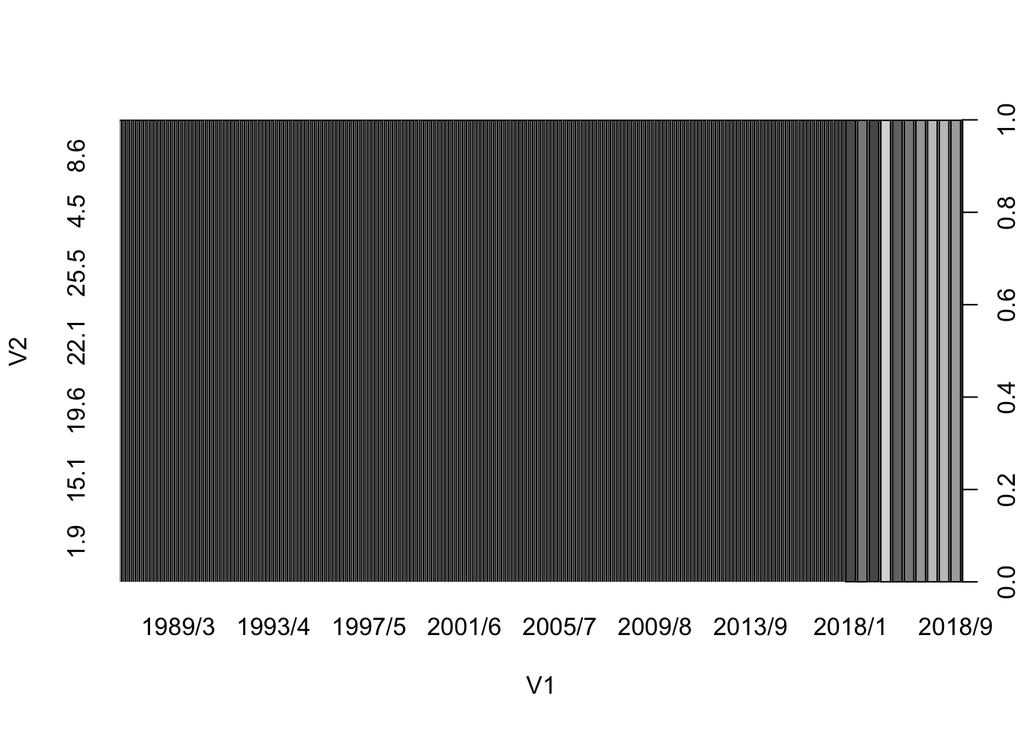

```r
#plot(f2018[,1], f2018[,2])
plot(f2018)
```

なんじゃこりゃ…

```r
str(f2018)
```

```
## 'data.frame':    10 obs. of  2 variables:
##  $ V1: Factor w/ 384 levels "","1987/1","1987/10",..: 374 376 377 378 379 380 381 382 383 375
##  $ V2: Factor w/ 201 levels "","-0.3","0.1",..: 11 7 177 29 53 89 138 134 96 54
```

あー，factor型になってる…

「年月」を，とりあえずその月の1日の，つまり「〜年〜月1日」とする。

```r
f2018[,1] <- as.Date(paste(f2018[,1], "/1", sep=""))
str(f2018)
```

```
## 'data.frame':    10 obs. of  2 variables:
##  $ V1: Date, format: "2018-01-01" "2018-02-01" ...
##  $ V2: Factor w/ 201 levels "","-0.3","0.1",..: 11 7 177 29 53 89 138 134 96 54
```

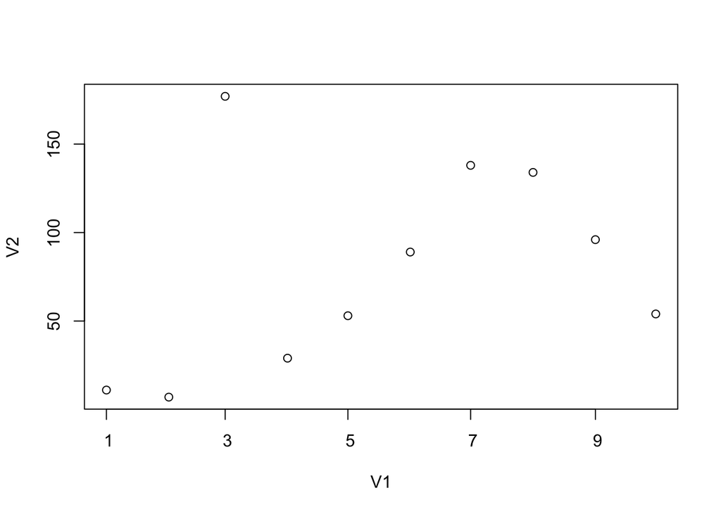

```r
plot(f2018)
```

気温とこもfactor型じゃダメか。

```r
f2018[,2] <- as.numeric(f2018[,2])
str(f2018)
```

```
## 'data.frame':    10 obs. of  2 variables:
##  $ V1: Date, format: "2018-01-01" "2018-02-01" ...
##  $ V2: num  11 7 177 29 53 89 138 134 96 54
```

あー，一度factor型になったら直で numericに変換してもダメか。

```r
f2018 <- subset(f, grepl("2018/", f[,1]), c(1,2))
f2018[,1] <- as.Date(paste(f2018[,1], "/1", sep=""))
f2018[,2] <- as.numeric(as.character(f2018[,2]))
str(f2018)
```

```
## 'data.frame':    10 obs. of  2 variables:
##  $ V1: Date, format: "2018-01-01" "2018-02-01" ...
##  $ V2: num  1.2 0.7 6.2 11 15.9 20.2 26 25.4 21 16.1
```

よさげ。plot してみる。

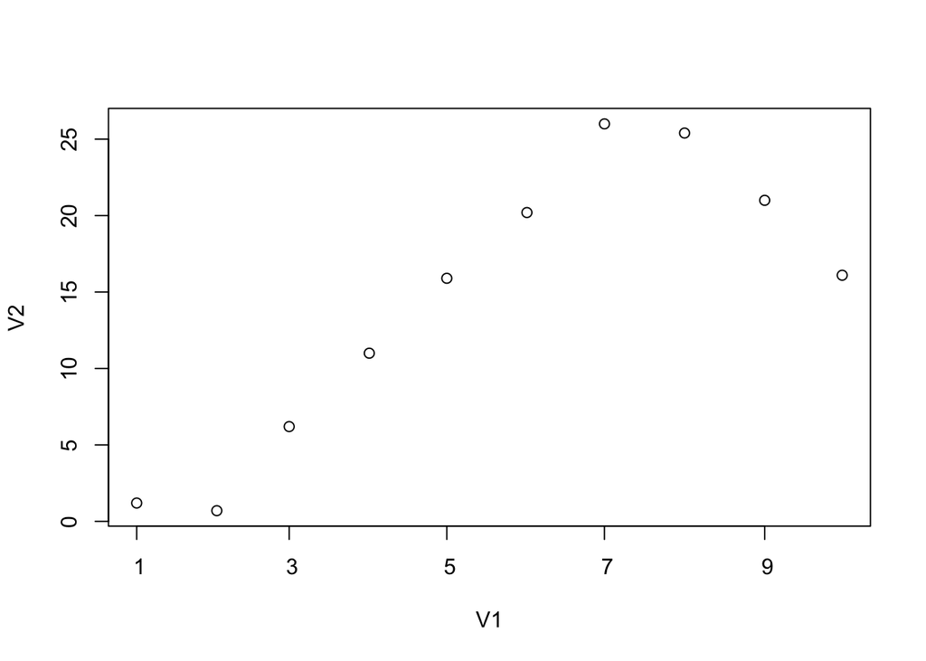

```r
plot(f2018)
```

読み込む段階から factor型にしなけりゃちょっと楽かも。

```r
f <- read.table('data.csv',sep=",", skip=1, header=F, fileEncoding = "Shift_JIS", stringsAsFactors=F)
f2018 <- subset(f, grepl("2018/", f[,1]), c(1,2))
f2018[,1] <- as.Date(paste(f2018[,1], "/1", sep=""))
f2018[,2] <- as.numeric(f2018[,2])
str(f2018)
```

```
## 'data.frame':    10 obs. of  2 variables:
##  $ V1: Date, format: "2018-01-01" "2018-02-01" ...
##  $ V2: num  1.2 0.7 6.2 11 15.9 20.2 26 25.4 21 16.1
```

線もつけてみる。

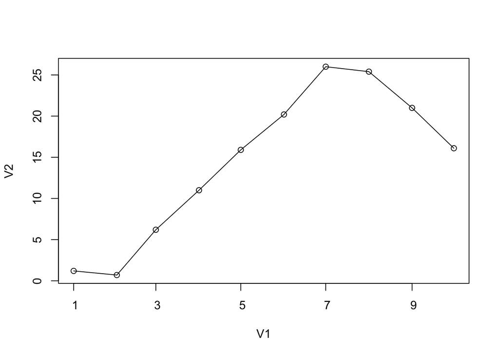

```r
plot(f2018, type="o")
```

最低気温，最高気温，降水量も欲しければ…

```r
f2018 <- subset(f, grepl("2018/", f[,1]), c(1,2,5,8,11))
f2018[,1] <- as.Date(paste(f2018[,1], "/1", sep=""))
n <- ncol(f2018)
for (i in 2:n) {
  f2018[,i] <- as.numeric(f2018[,i])
}
str(f2018)
```

```
## 'data.frame':    10 obs. of  5 variables:
##  $ V1 : Date, format: "2018-01-01" "2018-02-01" ...
##  $ V2 : num  1.2 0.7 6.2 11 15.9 20.2 26 25.4 21 16.1
##  $ V5 : num  4.1 3.9 10.9 15.4 20.4 24.3 30.1 29.7 25 20.6
##  $ V8 : num  -1.5 -2.3 1.7 7 12 16.5 22.8 21.7 17.5 12.2
##  $ V11: num  196 140 102 146 211 ...
```

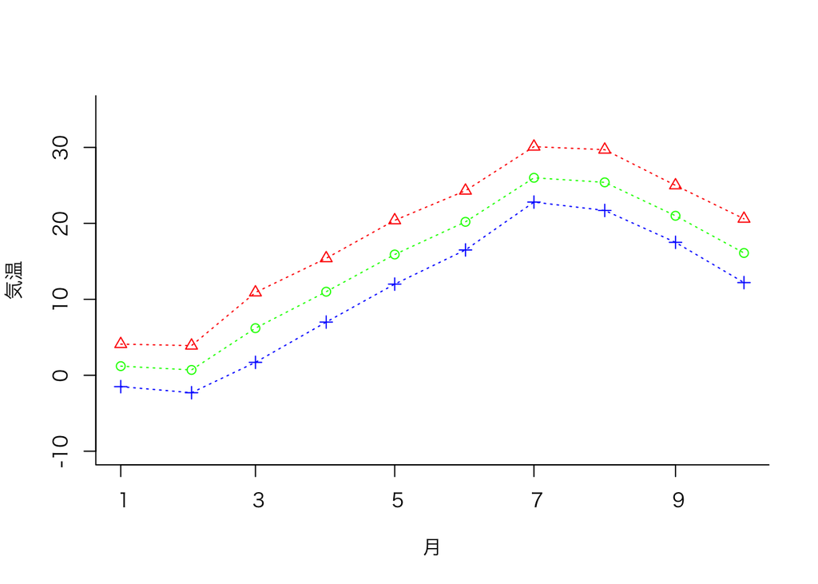

```r
par(family="HiraKakuPro-W3", lty=3, bty="l")

plot(f2018$V1, f2018$V2, type="o", ylim=c(-10,35), col=rgb(0,1,0), pch=1, xlab="月", ylab="気温")
par(new=T)
lines(f2018$V1, f2018$V5, type="o", ylim=c(-10,35), col=rgb(1,0,0), pch=2)
par(new=T)
lines(f2018$V1, f2018$V8, type="o", ylim=c(-10,35), col=rgb(0,0,1), pch=3)
```

```r
#par(new=T)
#barplot(f2018$V1, f2018$V11)
#axis(side=4)
```

## 月ごと平均気温の今までの平均

今までの平均を出す。

…の前に，データの整形。

今回は全部酒田のデータなので， 1行目の「酒田」はじゃま。

```r
f <- f[ -1,]
head(f)
```

```
##       V1           V2           V3           V4                   V5
## 2   年月 平均気温(℃) 平均気温(℃) 平均気温(℃) 日最高気温の平均(℃)
## 3                         品質情報     均質番号
## 4 1987/1          1.1            8            1                  4.0
## 5 1987/2          1.9            8            1                  4.9
## 6 1987/3          4.3            8            1                  7.9
## 7 1987/4          9.4            8            1                 14.5
##                     V6                   V7                   V8
## 2 日最高気温の平均(℃) 日最高気温の平均(℃) 日最低気温の平均(℃)
## 3             品質情報             均質番号
## 4                    8                    1                 -1.8
## 5                    8                    1                 -0.9
## 6                    8                    1                  0.7
## 7                    8                    1                  4.0
##                     V9                  V10              V11
## 2 日最低気温の平均(℃) 日最低気温の平均(℃) 降水量の合計(mm)
## 3             品質情報             均質番号
## 4                    8                    1            140.5
## 5                    8                    1            115.0
## 6                    8                    1            134.0
## 7                    8                    1             41.5
##                V12              V13              V14
## 2 降水量の合計(mm) 降水量の合計(mm) 降水量の合計(mm)
## 3     現象なし情報         品質情報         均質番号
## 4                0                8                1
## 5                0                8                1
## 6                0                8                1
## 7                0                8                1
```

んでもって1行目_2行目を列タイトルにする。 まず，各列の1行目_2行目を生成する関数作って列タイトル用のベクトルを。

```r
makeColumnName <- function(dfCol){
    retCol = dfCol[1]
  if (dfCol[2] != "") {
    retCol = paste(retCol,dfCol[2],sep="_")
  }
  return(retCol)
}

colTitle <- apply(f,2,makeColumnName)
colTitle
```

```
##                              V1                              V2
##                          "年月"                  "平均気温(℃)"
##                              V3                              V4
##         "平均気温(℃)_品質情報"         "平均気温(℃)_均質番号"
##                              V5                              V6
##          "日最高気温の平均(℃)" "日最高気温の平均(℃)_品質情報"
##                              V7                              V8
## "日最高気温の平均(℃)_均質番号"          "日最低気温の平均(℃)"
##                              V9                             V10
## "日最低気温の平均(℃)_品質情報" "日最低気温の平均(℃)_均質番号"
##                             V11                             V12
##              "降水量の合計(mm)" "降水量の合計(mm)_現象なし情報"
##                             V13                             V14
##     "降水量の合計(mm)_品質情報"     "降水量の合計(mm)_均質番号"
```

「(℃)」「(mm)」「の平均」「の合計」とかじゃま。

要らんとことる関数作ってmakeColumnNameに挟む。

```r
removeCharFromTitle1 <- function(string){
  return(gsub("(\\(.+\\))|(の.+)", "", string))
}

removeCharFromTitle2 <- function(string){
  return(gsub("(情報)|(番号)", "", string))
}

makeColumnName <- function(dfCol){
    retCol = removeCharFromTitle1(dfCol[1])
  if (dfCol[2] != "") {
    retCol = paste(retCol,removeCharFromTitle2(dfCol[2]),sep="_")
  }
  return(retCol)
}

colTitle <- apply(f,2,makeColumnName)
colTitle
```

```
##                V1                V2                V3                V4
##            "年月"        "平均気温"   "平均気温_品質"   "平均気温_均質"
##                V5                V6                V7                V8
##      "日最高気温" "日最高気温_品質" "日最高気温_均質"      "日最低気温"
##                V9               V10               V11               V12
## "日最低気温_品質" "日最低気温_均質"          "降水量" "降水量_現象なし"
##               V13               V14
##     "降水量_品質"     "降水量_均質"
```

タイトルに設定。

```r
colnames(f) <- colTitle
head(f)
```

```
##     年月     平均気温 平均気温_品質 平均気温_均質           日最高気温
## 2   年月 平均気温(℃)  平均気温(℃)  平均気温(℃) 日最高気温の平均(℃)
## 3                          品質情報      均質番号
## 4 1987/1          1.1             8             1                  4.0
## 5 1987/2          1.9             8             1                  4.9
## 6 1987/3          4.3             8             1                  7.9
## 7 1987/4          9.4             8             1                 14.5
##        日最高気温_品質      日最高気温_均質           日最低気温
## 2 日最高気温の平均(℃) 日最高気温の平均(℃) 日最低気温の平均(℃)
## 3             品質情報             均質番号
## 4                    8                    1                 -1.8
## 5                    8                    1                 -0.9
## 6                    8                    1                  0.7
## 7                    8                    1                  4.0
##        日最低気温_品質      日最低気温_均質           降水量
## 2 日最低気温の平均(℃) 日最低気温の平均(℃) 降水量の合計(mm)
## 3             品質情報             均質番号
## 4                    8                    1            140.5
## 5                    8                    1            115.0
## 6                    8                    1            134.0
## 7                    8                    1             41.5
##    降水量_現象なし      降水量_品質      降水量_均質
## 2 降水量の合計(mm) 降水量の合計(mm) 降水量の合計(mm)
## 3     現象なし情報         品質情報         均質番号
## 4                0                8                1
## 5                0                8                1
## 6                0                8                1
## 7                0                8                1
```

1,2行目削除。

```r
f <- f[-1:-2,]
head(f)
```

```
##     年月 平均気温 平均気温_品質 平均気温_均質 日最高気温 日最高気温_品質
## 4 1987/1      1.1             8             1        4.0               8
## 5 1987/2      1.9             8             1        4.9               8
## 6 1987/3      4.3             8             1        7.9               8
## 7 1987/4      9.4             8             1       14.5               8
## 8 1987/5     15.4             8             1       20.5               8
## 9 1987/6     20.1             8             1       24.8               8
##   日最高気温_均質 日最低気温 日最低気温_品質 日最低気温_均質 降水量
## 4               1       -1.8               8               1  140.5
## 5               1       -0.9               8               1  115.0
## 6               1        0.7               8               1  134.0
## 7               1        4.0               8               1   41.5
## 8               1       10.7               8               1  105.0
## 9               1       15.5               8               1   46.0
##   降水量_現象なし 降水量_品質 降水量_均質
## 4               0           8           1
## 5               0           8           1
## 6               0           8           1
## 7               0           8           1
## 8               0           8           1
## 9               0           8           1
```

「年/月」を，その月の1日の日付型に。

```r
f[,1] <- as.Date(paste(f[,1], "/1", sep=""))
```

年月日のとこの“XXXX/1”, “XXXX/2” ごと，要するに月ごとに今までのデータまとめる。

“年/月” の月の部分，“month”の列にfactor型で入れる。

```r
monthLabel <- function(x){
    return(format(x, "%m"))
}

f$month <- as.factor(sapply(f$年月, monthLabel))
str(f)
```

```
## 'data.frame':    382 obs. of  15 variables:
##  $ 年月           : Date, format: "1987-01-01" "1987-02-01" ...
##  $ 平均気温       : chr  "1.1" "1.9" "4.3" "9.4" ...
##  $ 平均気温_品質  : chr  "8" "8" "8" "8" ...
##  $ 平均気温_均質  : chr  "1" "1" "1" "1" ...
##  $ 日最高気温     : chr  "4.0" "4.9" "7.9" "14.5" ...
##  $ 日最高気温_品質: chr  "8" "8" "8" "8" ...
##  $ 日最高気温_均質: chr  "1" "1" "1" "1" ...
##  $ 日最低気温     : chr  "-1.8" "-0.9" "0.7" "4.0" ...
##  $ 日最低気温_品質: chr  "8" "8" "8" "8" ...
##  $ 日最低気温_均質: chr  "1" "1" "1" "1" ...
##  $ 降水量         : chr  "140.5" "115.0" "134.0" "41.5" ...
##  $ 降水量_現象なし: chr  "0" "0" "0" "0" ...
##  $ 降水量_品質    : chr  "8" "8" "8" "8" ...
##  $ 降水量_均質    : chr  "1" "1" "1" "1" ...
##  $ month          : Factor w/ 12 levels "01","02","03",..: 1 2 3 4 5 6 7 8 9 10 ...
```

```r
#head(sapply(f$年月, monthLabel))
```

「_」でつないだとこ（品質情報，均質番号，現象なし）はfactor型に。

「_」でつないだ列を返す関数作ってとりあえず泥臭く for で回す。

```r
combinedColumn <- function(df) {
    return(grepl(".+_.+", colnames(df)))
}

for (i in which(combinedColumn(f))) {
    f[,i] <- as.factor(f[,i])
}
str(f)
```

```
## 'data.frame':    382 obs. of  15 variables:
##  $ 年月           : Date, format: "1987-01-01" "1987-02-01" ...
##  $ 平均気温       : chr  "1.1" "1.9" "4.3" "9.4" ...
##  $ 平均気温_品質  : Factor w/ 2 levels "5","8": 2 2 2 2 2 2 2 2 2 2 ...
##  $ 平均気温_均質  : Factor w/ 1 level "1": 1 1 1 1 1 1 1 1 1 1 ...
##  $ 日最高気温     : chr  "4.0" "4.9" "7.9" "14.5" ...
##  $ 日最高気温_品質: Factor w/ 2 levels "5","8": 2 2 2 2 2 2 2 2 2 2 ...
##  $ 日最高気温_均質: Factor w/ 1 level "1": 1 1 1 1 1 1 1 1 1 1 ...
##  $ 日最低気温     : chr  "-1.8" "-0.9" "0.7" "4.0" ...
##  $ 日最低気温_品質: Factor w/ 2 levels "5","8": 2 2 2 2 2 2 2 2 2 2 ...
##  $ 日最低気温_均質: Factor w/ 1 level "1": 1 1 1 1 1 1 1 1 1 1 ...
##  $ 降水量         : chr  "140.5" "115.0" "134.0" "41.5" ...
##  $ 降水量_現象なし: Factor w/ 1 level "0": 1 1 1 1 1 1 1 1 1 1 ...
##  $ 降水量_品質    : Factor w/ 2 levels "5","8": 2 2 2 2 2 2 2 2 2 2 ...
##  $ 降水量_均質    : Factor w/ 1 level "1": 1 1 1 1 1 1 1 1 1 1 ...
##  $ month          : Factor w/ 12 levels "01","02","03",..: 1 2 3 4 5 6 7 8 9 10 ...
```

「平均気温」「日最高気温」「降水量」などのデータ部分(colnames が「年月」「month」以外で，しかも「_」ない)の列吐き出す関数作って，その列は numeric型に変換。

```r
dataColumn <- function(df) {
  dataFlag1 = !grepl("(.+_.+)", colnames(df))
  dataFlag2 = !grepl("(年月)|(month)", colnames(df))
  return( as.logical(dataFlag1*dataFlag2) )
}

for (i in which(dataColumn(f))) {
    f[,i] <- as.numeric(f[,i])
}
str(f)
```

```
## 'data.frame':    382 obs. of  15 variables:
##  $ 年月           : Date, format: "1987-01-01" "1987-02-01" ...
##  $ 平均気温       : num  1.1 1.9 4.3 9.4 15.4 20.1 23.5 24.6 21.3 15.5 ...
##  $ 平均気温_品質  : Factor w/ 2 levels "5","8": 2 2 2 2 2 2 2 2 2 2 ...
##  $ 平均気温_均質  : Factor w/ 1 level "1": 1 1 1 1 1 1 1 1 1 1 ...
##  $ 日最高気温     : num  4 4.9 7.9 14.5 20.5 24.8 27.2 28.4 25.8 20.1 ...
##  $ 日最高気温_品質: Factor w/ 2 levels "5","8": 2 2 2 2 2 2 2 2 2 2 ...
##  $ 日最高気温_均質: Factor w/ 1 level "1": 1 1 1 1 1 1 1 1 1 1 ...
##  $ 日最低気温     : num  -1.8 -0.9 0.7 4 10.7 15.5 20.4 21.2 17.6 11 ...
##  $ 日最低気温_品質: Factor w/ 2 levels "5","8": 2 2 2 2 2 2 2 2 2 2 ...
##  $ 日最低気温_均質: Factor w/ 1 level "1": 1 1 1 1 1 1 1 1 1 1 ...
##  $ 降水量         : num  140.5 115 134 41.5 105 ...
##  $ 降水量_現象なし: Factor w/ 1 level "0": 1 1 1 1 1 1 1 1 1 1 ...
##  $ 降水量_品質    : Factor w/ 2 levels "5","8": 2 2 2 2 2 2 2 2 2 2 ...
##  $ 降水量_均質    : Factor w/ 1 level "1": 1 1 1 1 1 1 1 1 1 1 ...
##  $ month          : Factor w/ 12 levels "01","02","03",..: 1 2 3 4 5 6 7 8 9 10 ...
```

ちなみに項目名。

```r
colnames(f)[dataColumn(f)]
```

```
## [1] "平均気温"   "日最高気温" "日最低気温" "降水量"
```

ついでに年月。

```r
paste(format(min(f$年月), "%Y/%m"), format(max(f$年月), "%Y/%m"), sep = " 〜 ")
```

```
## [1] "1987/01 〜 2018/10"
```

これで基本の準備はOK。

試しに，平均気温のヒストグラム。

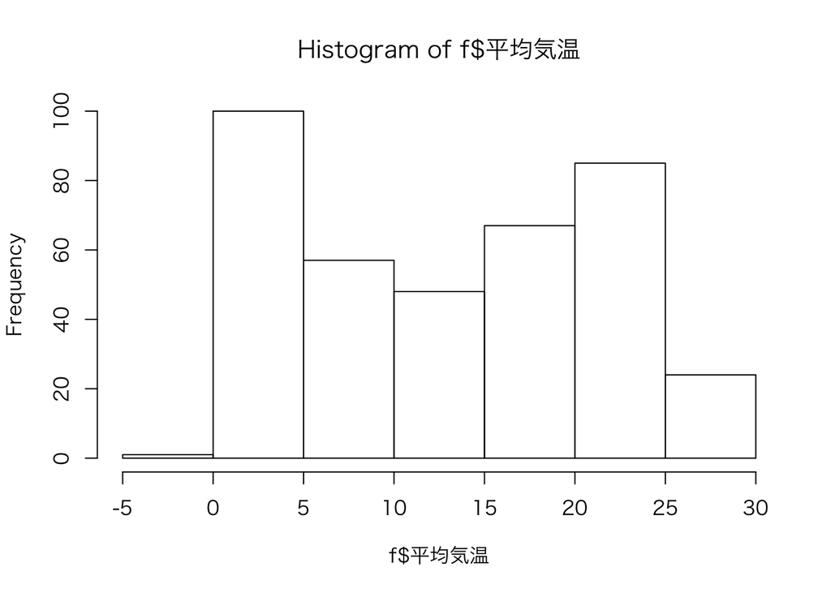

```r
#f[,2]
par(family="HiraKakuPro-W3", bty="l")
hist(f$平均気温)
```

ヘェ〜山型じゃないんだ。

各月(f$month)の平均気温(f$平均気温)の，今までの平均(mean)。

```r
avrTempByMonth <- tapply(f$平均気温, f$month, mean)
avrTempByMonth
```

```
##        01        02        03        04        05        06        07
##  1.837500  2.068750  4.953125 10.240625 15.590625 19.953125 23.740625
##        08        09        10        11        12
## 25.450000 21.431250 15.487500  9.590323  4.554839
```

グラフに。

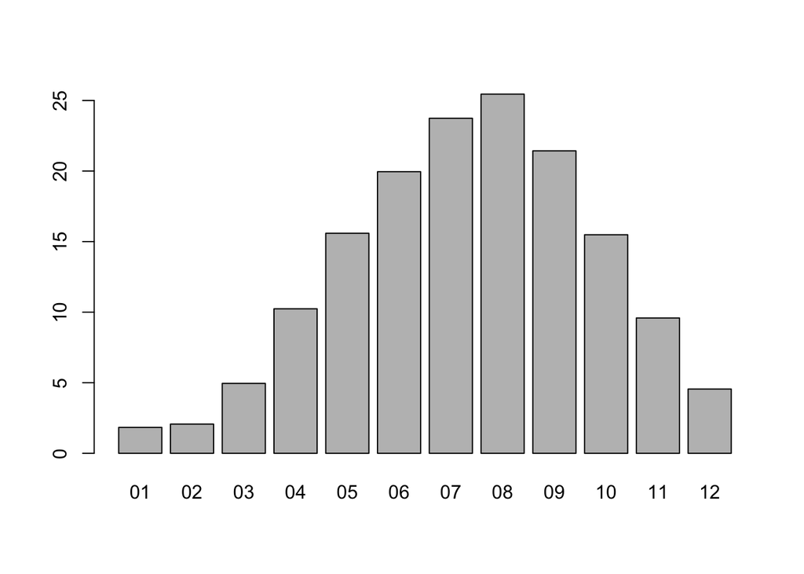

```r
#par(family="HiraKakuPro-W3", bty="l")

barplot(avrTempByMonth)
```

```r
#par(new=T)
#lines(f2018$V1, f2018$V5, type="o", ylim=c(-10,35), col=rgb(1,0,0), pch=2)
#par(new=T)
#lines(f2018$V1, f2018$V8, type="o", ylim=c(-10,35), col=rgb(0,0,1), pch=3)
```

エラーバーで分散(標準偏差)もつける時はこう。

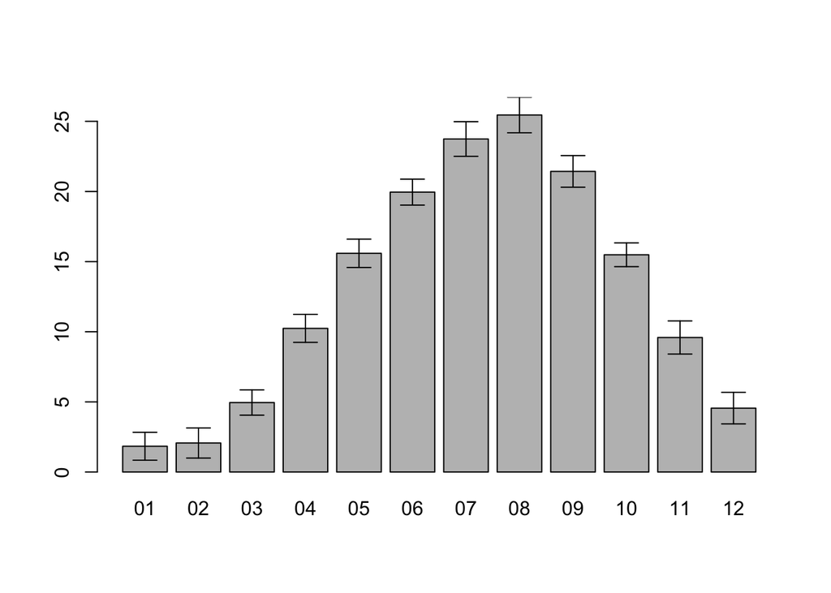

```r
varTempByMonth1 <- tapply(f$平均気温, f$month, sd)
bp <- barplot(avrTempByMonth, ylim = c(0, max(avrTempByMonth + varTempByMonth1)))

arrows(bp, avrTempByMonth - varTempByMonth1, bp, avrTempByMonth + varTempByMonth1, code = 3, lwd = 1, angle = 90, length = 0.1)
```

2018年の平均気温に，過去の分の標準偏差(エラーバー)つけると

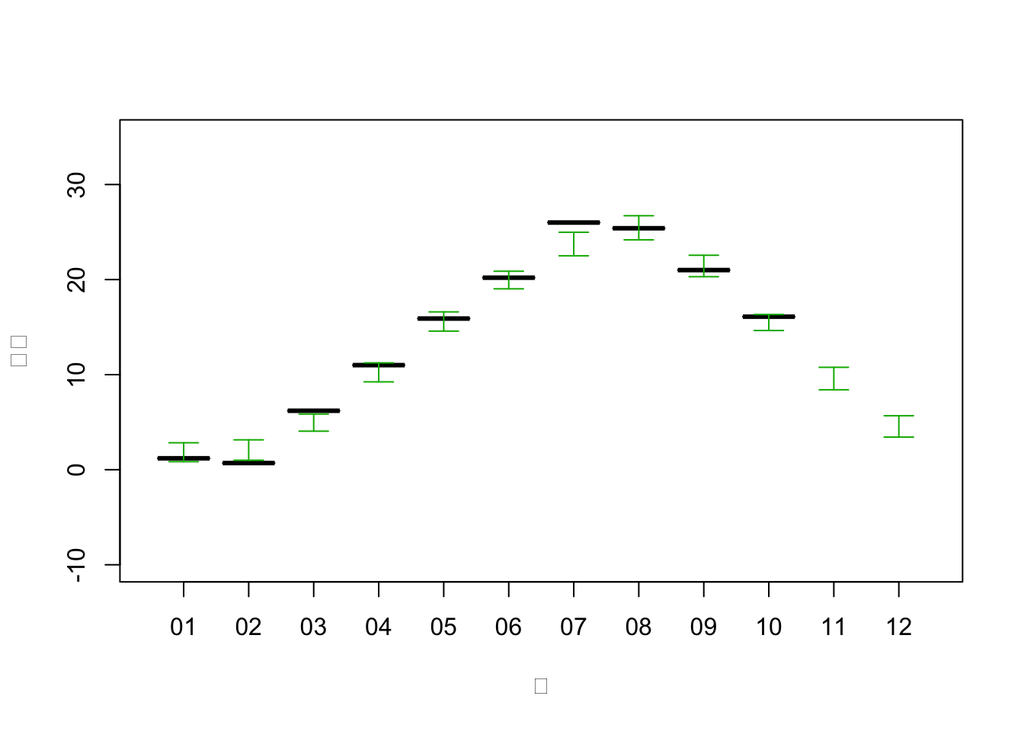

```r
f2018 <- subset(f, grepl("2018", format(f$年月, "%Y")))
plot(f2018[,c("month","平均気温")], type="o", ylim=c(-10,35), col=rgb(0,0.7,0), pch=1, xlab="月", ylab="気温")
arrows(c(1:12), avrTempByMonth - varTempByMonth1, c(1:12), avrTempByMonth + varTempByMonth1, code = 3, lwd = 1, angle = 90, length = 0.1, ylim=c(-10,35), lty=1, col=rgb(0,0.7,0))
```

わからいでもないが，やっぱ変。

```r
f2018[,c("month","平均気温")]
```

```
##     month 平均気温
## 376    01      1.2
## 377    02      0.7
## 378    03      6.2
## 379    04     11.0
## 380    05     15.9
## 381    06     20.2
## 382    07     26.0
## 383    08     25.4
## 384    09     21.0
## 385    10     16.1
```

11・12月がないからエラーバーの方とデータの数が合わない。

ないなら付け足す。とりあえず必要な分だけピックアップして…

```r
#f2018 <- subset(f, grepl("2018", format(f$年月, "%Y")))
pickData <- function(df, itemName) {
  return(df[,c("month", itemName)])
}

f2018avrtmp <- pickData(f2018, "平均気温")
f2018avrtmp
```

```
##     month 平均気温
## 376    01      1.2
## 377    02      0.7
## 378    03      6.2
## 379    04     11.0
## 380    05     15.9
## 381    06     20.2
## 382    07     26.0
## 383    08     25.4
## 384    09     21.0
## 385    10     16.1
```

```r
f2018month <- as.numeric(f2018avrtmp$month)
max(f2018month)
```

```
## [1] 10
```

ということで，これ+1から12までのベクトル作る。

```r
addingMonthNum = (max(f2018month)+1):12
addingMonthNum
```

```
## [1] 11 12
```

このままだと数字なんで，これを 0 paddingした文字列に直す。

```r
addingMonthString <- sprintf("%02d", addingMonthNum)
addingMonthString
```

```
## [1] "11" "12"
```

…2桁だとわからんから関数作ってテスト。

```r
paddingString <- function(numVec){
  addingMonthNum <- (max(numVec)+1):12
  addingMonthString <- sprintf("%02d", addingMonthNum)
  return(addingMonthString)
}

paddingString(1:8)
```

```
## [1] "09" "10" "11" "12"
```

大丈夫そう。ここまでをまとめると

```r
paddingString <- function(numVec){
  addingMonthNum <- (max(numVec)+1):12
  addingMonthString <- sprintf("%02d", addingMonthNum)
  return(addingMonthString)
}

notYetMonthVec <- function(yearDF){
  itemDF <- yearDF[,c("month")]
  itemDFWithNumMonth <- as.numeric(itemDF)
  notYetMonthStringVec <- paddingString(itemDFWithNumMonth)
  return(notYetMonthStringVec)
}
notYetMonthVec(f2018)
```

```
## [1] "11" "12"
```

これを付け足す関数。“month”,“平均気温”の順で取り出してるんで…

```r
pickData <- function(df, itemName) {
  return(df[,c("month", itemName)])
}

f2018avrtmp <- pickData(f2018, "平均気温")
addRestMonth <- function(monthDataDF, paddinfStringsVec){
  for (i in paddinfStringsVec) {
    monthDataDF <- rbind(monthDataDF, c(i,""))
  }
  return(monthDataDF)
}

f2018forPlot <- addRestMonth(f2018avrtmp, notYetMonthVec(f2018))
f2018forPlot
```

```
##     month 平均気温
## 376    01      1.2
## 377    02      0.7
## 378    03      6.2
## 379    04       11
## 380    05     15.9
## 381    06     20.2
## 382    07       26
## 383    08     25.4
## 384    09       21
## 385    10     16.1
## 11     11
## 12     12
```

よし。

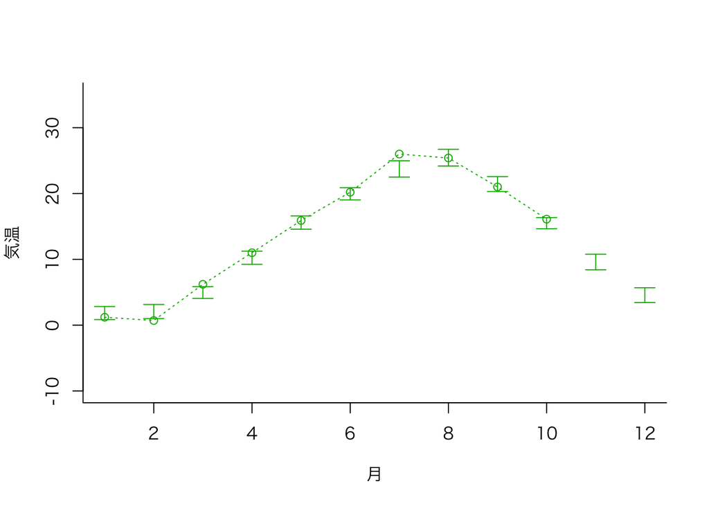

```r
par(family="HiraKakuPro-W3", lty=3, bty="l")
plot(f2018forPlot, type="o", ylim=c(-10,35), col=rgb(0,0.7,0), pch=1, xlab="月", ylab="気温")
arrows(c(1:12), avrTempByMonth - varTempByMonth1, c(1:12), avrTempByMonth + varTempByMonth1, code = 3, lwd = 1, angle = 90, length = 0.1, ylim=c(-10,35), lty=1, col=rgb(0,0.7,0))
```

完成形。

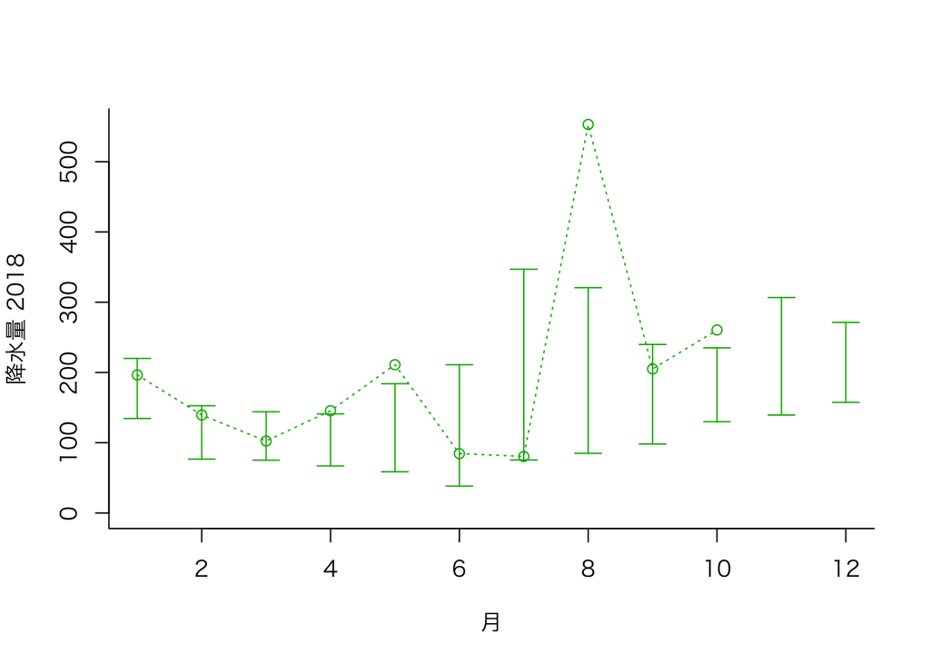

```r
paddingString <- function(numVec){
  addingMonthNum <- (max(numVec)+1):12
  addingMonthString <- sprintf("%02d", addingMonthNum)
  return(addingMonthString)
}

notYetMonthVec <- function(yearDF){
  itemDF <- yearDF[,c("month")]
  if (length(itemDF) < 12){
  itemDFWithNumMonth <- as.numeric(itemDF)
  notYetMonthStringVec <- paddingString(itemDFWithNumMonth)
  return(notYetMonthStringVec)
  } else {
    return(c())
  }
}

pickData <- function(df, itemName) {
  return(df[,c("month", itemName)])
}

addRestMonth <- function(monthDataDF, paddinfStringsVec){
  for (i in paddinfStringsVec) {
    monthDataDF <- rbind(monthDataDF, c(i,""))
  }
#  monthDataDF[,2] <- as.numeric(monthDataDF[,2])
  return(monthDataDF)
}

plotYear <- function(yearDF, itemName){
  yearDFForPlotTmp <- pickData(yearDF, itemName)
  yearDFForPlot <- addRestMonth(yearDFForPlotTmp, notYetMonthVec(yearDF))
  return(yearDFForPlot)
}

getYearDF <- function(jmaDF, pickedYear){
  yearDF <- subset(jmaDF, grepl(pickedYear, format(jmaDF$年月, "%Y")))
#str(yearDF)
    return(yearDF)
}

getSDBar <- function(jmaDF, itemName){
  avrByMonth <- tapply(jmaDF[,c(itemName)], jmaDF$month, mean)
  sdByMonth <- tapply(jmaDF[,c(itemName)], jmaDF$month, sd)
  resultSDVec <- list(avrByMonth, sdByMonth)
  names(resultSDVec) <- c("avr", "sd")
  return(resultSDVec)
}

plotDotLine <- function(df, year, itemName) {
# ある年のある項目のデータ
  resultDF <- plotYear(getYearDF(df, year), itemName)
# その項目の，今までの平均値と標準偏差
  resultSD <- getSDBar(df, itemName)
# その年の，項目の数字の最大値・最小値(欠損値除く)
  yDataMin <- min(as.numeric(resultDF[,2]), na.rm = T)
  yDataMax <- max(as.numeric(resultDF[,2]), na.rm = T)
# 平均値+標準偏差の最大値
  ySDMin <- min(resultSD$avr - resultSD$sd, na.rm = T)
  # 平均値-標準偏差の最小値
  ySDMax <- max(resultSD$avr + resultSD$sd, na.rm = T)

# その年のと平均値〜と，どっちか大きい/小さい方(ただし最小値は0含む)
  yMin <- min(yDataMin, ySDMin, 0)
  yMax <- max(yDataMax, ySDMax)
  resultVec <- list(data=resultDF[,2], avr=resultSD$avr, sd=resultSD$sd, ylim=c(yMin, yMax), axtxt=paste(itemName, year))
  return(resultVec)
}

# example
pldata <- plotDotLine(f, "2018", "降水量")
ydata <- pldata$data
allAvr <- pldata$avr
allSD <- pldata$sd
allylim <- pldata$ylim
axtxt <- pldata$axtxt

par(family = "HiraKakuPro-W3", lty = 3, bty = "l")
plot(
  ydata,
  type = "o",
  ylim = allylim,
  col = rgb(0, 0.7, 0),
  pch = 1,
  xlab = "月",
  ylab = axtxt
)
arrows(
  c(1:12),
  allAvr - allSD,
  c(1:12),
  allAvr + allSD,
  code = 3,
  lwd = 1,
  angle = 90,
  length = 0.1,
  ylim = allylim,
  lty = 1,
  col = rgb(0, 0.7, 0)
)
```

```r
#c(yDataMin, yDataMax, ySDMin, ySDMax)
#str(resultDF)
```

散布図

```r
allData <- plotYear(f, "降水量")
yMax <- max(allData[,2])
plot(allData, pch=1, xlim=c(1,12), ylim=c(0,yMax), col="#ffffff")
par(new=T)
allData[,1] <- as.numeric(as.character(allData[,1]))
str(allData)
```

```
## 'data.frame':    382 obs. of  2 variables:
##  $ month : num  1 2 3 4 5 6 7 8 9 10 ...
##  $ 降水量: num  140.5 115 134 41.5 105 ...
```

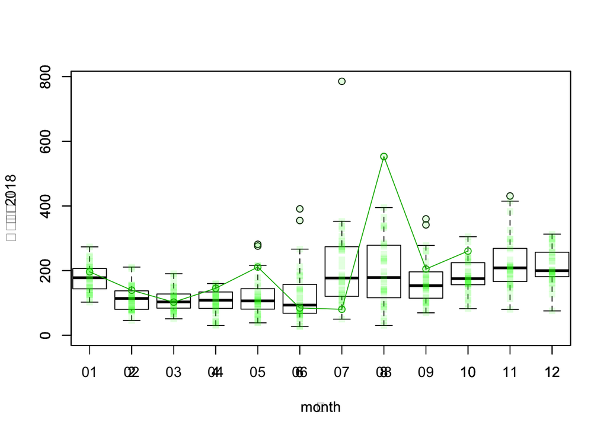

```r
plot(allData, pch=15, xlim=c(1,12), ylim=c(0,yMax), col="#00ff0020")
par(new=T)
plot(
  ydata,
  type = "o",
  ylim = c(0,yMax),
  col = rgb(0, 0.7, 0),
  pch = 1,
  xlab = "月",
  ylab = axtxt
)
```